[output not shown]

## Learning Goals

Developing deep learning to two core questions in supervised learning: Classification and Regression.

## Outline

- What is a tensor and why use it?
- What is keras and what is its relationship to TensorFlow?
- What is the deep in deep learning? ANNs and densely-connected networks.
- The math of deep learning: Basics of matrix algebra, gradient descent, backpropagarion, chain rule.
- The four stages of Deep learning.
- Parameters and hyper-parameter.
- Functions distinguishing classification and regression: loss and optimizer functions.

## Functions in this session:

(#tab:FunIa) Basic `keras` functions.

| Function | Description |
| --- | --- |
| [`keras_model_sequential()`](https://www.rdocumentation.org/packages/keras/versions/2.2.0/topics/keras_model_sequential) | Keras Model composed of a linear stack of layers. |
| `layer_dense()` | Add a densely-connected NN layer to an output. |
| `compile()` | Configure a Keras model for training. |
| `fit()` | Train a Keras model. |

```r
knitr::kable(mtcars[1:5,])
```

|  | mpg | cyl | disp | hp | drat | wt | qsec | vs | am | gear | carb |
| --- | --- | --- | --- | --- | --- | --- | --- | --- | --- | --- | --- |
| Mazda RX4 | 21.0 | 6 | 160 | 110 | 3.90 | 2.620 | 16.46 | 0 | 1 | 4 | 4 |
| Mazda RX4 Wag | 21.0 | 6 | 160 | 110 | 3.90 | 2.875 | 17.02 | 0 | 1 | 4 | 4 |
| Datsun 710 | 22.8 | 4 | 108 | 93 | 3.85 | 2.320 | 18.61 | 1 | 1 | 4 | 1 |
| Hornet 4 Drive | 21.4 | 6 | 258 | 110 | 3.08 | 3.215 | 19.44 | 1 | 0 | 3 | 1 |
| Hornet Sportabout | 18.7 | 8 | 360 | 175 | 3.15 | 3.440 | 17.02 | 0 | 0 | 3 | 2 |

[output not shown]

[output not shown]

[output not shown]

[output not shown]

[output not shown]

```r
knitr::kable(iris[1:5, ], caption = 'A caption')
```

A caption

| Sepal.Length | Sepal.Width | Petal.Length | Petal.Width | Species |
| --- | --- | --- | --- | --- |
| 5.1 | 3.5 | 1.4 | 0.2 | setosa |
| 4.9 | 3.0 | 1.4 | 0.2 | setosa |
| 4.7 | 3.2 | 1.3 | 0.2 | setosa |
| 4.6 | 3.1 | 1.5 | 0.2 | setosa |
| 5.0 | 3.6 | 1.4 | 0.2 | setosa |

| Notation | Description |
| --- | --- |
| `>` | The R command prompt. |
| `n` | An object name. |
| `<-` | The assign operator. |
| `log2()` | The function to be solved. The solution will be assigned to n. |
| `8` | The function’s argument. |
| `#` | The beginning of the comment. |
| `The logarithm of ...` | The comment. |
| `[]` | Refers to the index of the output. |
| `1` | The index number. |
| `3` | The value at position `[1]`. |

(#tab:syntax) R’s syntax.

| Notation | Description |
| --- | --- |
| `>` | The R command prompt. |
| `n` | An object name. |
| `<-` | The assign operator. |
| `log2()` | The function to be solved. The solution will be assigned to n. |
| `8` | The function’s argument. |
| `#` | The beginning of the comment. |
| `The logarithm of ...` | The comment. |
| `[]` | Refers to the index of the output. |
| `1` | The index number. |
| `3` | The value at position `[1]`. |

And another one:

| Function | Description |
| --- | --- |
| [`keras_model_sequential()`](https://www.rdocumentation.org/packages/keras/versions/2.2.0/topics/keras_model_sequential) | Keras Model composed of a linear stack of layers. |
| `layer_dense()` | Add a densely-connected NN layer to an output. |
| `compile()` | Configure a Keras model for training. |

[output not shown]

## Abalone Examples

| Variable | Type | Unit | Description |
| --- | --- | --- | --- |
| sex | nominal | – | M, F, and I (infant) |
| length | continuous | mm | Longest shell measurement |
| diameter | continuous | mm | perpendicular to length |
| height | continuous | mm | with meat in shell |
| whole_weight | continuous | grams | whole abalone |
| shucked_weight | continuous | grams | weight of meat |
| viscera_weight | continuous | grams | gut weight (after bleeding) |
| shell_weight | continuous | grams | after being dried |
| rings | integer | – | +1.5 gives the age in years |

The number of rings, variable `rings`, is the value to predict as either a continuous value or as a classification problem.

```r
abalone <- read.csv("Abalone/abalone.data",
                   col.names = c("sex",
                                 "length",
                                 "diameter",
                                 "height",
                                 "whole_weight",
                                 "shucked_weight",
                                 "viscera_weight",
                                 "shell_weight",
                                 "rings"))
```

### Explore the data set

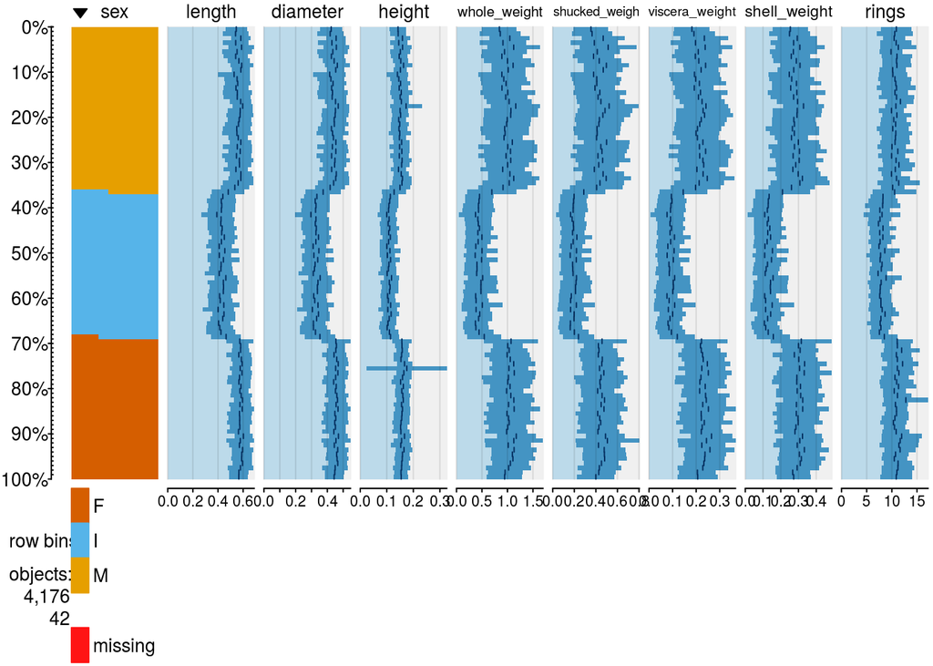

```r
library(ggplot2)
tabplot::tableplot(abalone)
```

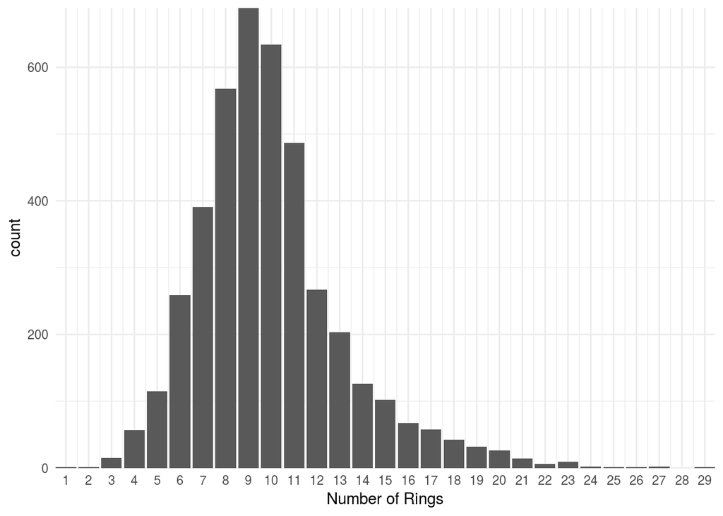

```r
ggplot(abalone, aes(rings)) +
  geom_bar() +
  scale_x_continuous("Number of Rings", breaks = 1:29) +
  coord_cartesian(expand = 0) +
  theme_minimal()
```

```r
# options(scipen=999)
train_n <- round(0.8*nrow(abalone))
test_n <- round(0.2*(nrow(abalone)))
```

number of training instances n = 3341.

number of test instances n = 835.

number of features d = 8.

number of classes K = 28.

```r
abalone_results <- abalone[,9]
abalone_data <- abalone[1:8]

# 3342/(3342 + 835)
```

### Split up training and test